# Mean age of first reproduction

Erin Feichtinger

Friday, April 29, 2016

# Lifetime event

From Bruce’s comments on the manuscript regarding the residences times of individuals in each stage from the fundamental matrix comes this…

### Estimating the expected age of first reproduction

I wrote functions for each step in the process. I used the orca whale data to test the functions and I get the same answer as Caswell in each step and the estimate for the mean age of first reproduction for orcas. Then, I arbitrarily chose values for each parameter in the growth model (single type) to see what number I get. Then, I repeated the process for the two type model.

I think I have the correct elements in the T’ and M’ matrices. I’m confused on one detail, however. $t_{i,j}$ is an element of T (original transition matrix) and it is the probability that an individual in stage j at time t is alive and in stage i and time t + 1. As I understand it, this would be sg.

```
##          [,1]     [,2]
## [1,] 1.462585 3.333333
```

The expected age of first reproduction in this example is 1.46. However, this is with no variation in growth and one phenotype only. I added the steps to find expected age of first reproduction to the simulation (2 types with sigma as a standard deviation). The average age at first reproduction is higher, 2. something for both phenoytpes. Not sure why, not sure it matters…?

Anyway, I was successful in adding the additional steps to the simulation and collecting the output of interest, the mean age of first reproduction for each phenotype. I checked the set up of T’ and M’ several times so I’m fairly confident that I placed the elements in the correct place within the matrices.

I only ran the program with one value of juvenile survival so I could save time and make sure the program worked. It takes about 15 minutes to go through the simulation with one value of S. Each additional value adds 15-20 minutes. 4 values of S takes about an hour. Now that I know it works, I can re-run the program with more values of S (although none of the other results depended very strongly on S).

- Range 2.031250 to 2.463782
- Mean of the expected age
  - slow = 2.130505, SD = 0.115
  - fast = 2.107819, SD = 0.057

I think this makes sense but a discussion is needed.

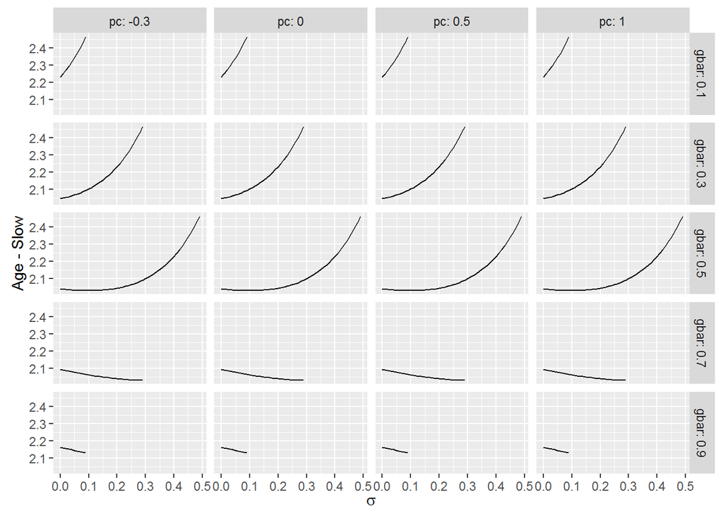

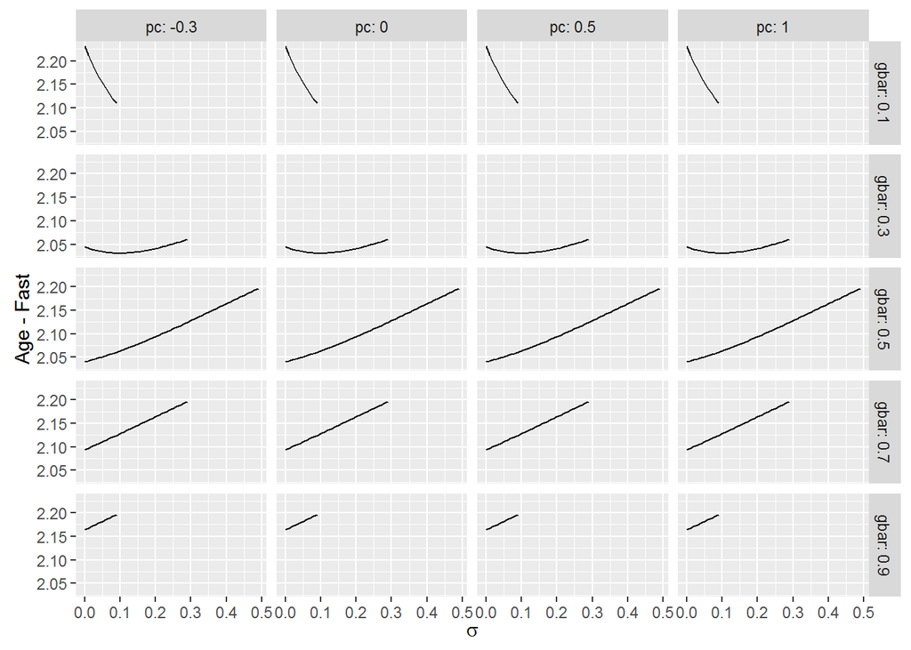

Results don’t appear to be dependent on phi, looks like g and sigma are key here. I don’t know what to think of this.